# Detailed Data Analysis: chefkoch.de

#### Applying these methods to the DataFrame for feature generation

After we have discovered the tools to split up ingredients, we can apply these techniques to the DataFrame.

```python
# Creating a new data frame, because the features will be high-dimensional
ingredf = pd.DataFrame()
ingredf['ingredients'] = clickdf['ingredients']
ingredf['ingredients'] = clickdf['ingredients']
ingredf.index = clickdf.index

ingredf.head(10)
```

|  | ingredients |
| --- | --- |
| 3169 | [12große, Pfeffer,frischgemahlen, ButteroderMa... |
| 384 | [800g, Hokkaidokürbis(se),geputztgewogen, 600g... |
| 1083 | [500g, 1, 2, 1Bund, PetersilieoderTK, 1EL, Tom... |
| 531 | [3, Eigelb, 75g, Zucker, 40ml, Amaretto, 500g,... |
| 790 | [560g, Mehl, 160g, Zucker, 400g, ButteroderMar... |
| 619 | [500g, 3Stange/n, Lauch, 250g, Schmelzkäse, 1B... |
| 3328 | [800g, 2, Chilischote(n),rote, 2große, 1Zehe/n... |
| 1415 | [4, 400g, Mehl, 100ml, 400ml, Milch, 1Pck., Va... |
| 193 | [1Becher, Schlagsahne,200g,geschlagen, 2Becher... |
| 527 | [500g, 200g, 1Bund, Rucola, 1Glas, 1kl.Glas, O... |

```python
# Cleaning
def clean_ingredients(text):
    # Remove characters
    for word in text:
        for char in ['"','-','=','!','(',')','.','♥',',',':','~','„','“','/','–','&','+',';','*','☆']:
            if char in word:
                word = word.replace(char,' ')

    # Filter empty list entries
    text = list(filter(None, text))

    # Filter all stop words defined above
    for stop in stopwords:
        text = list(filter(lambda k: stop != k, text))
    for stop in remove:
        text = list(filter(lambda k: stop != k, text))

    # Remove numbers
    text = [t for t in text if not containsNumbers(t)]

    # Remove n.B.
    text = [t for t in text if t != 'n.B.']

    return text
```

```python
ingredf['inglist'] = ingredf['ingredients'].apply(clean_ingredients)
ingredf.head(10)
```

|  | ingredients | inglist |
| --- | --- | --- |
| 3169 | [12große, Pfeffer,frischgemahlen, ButteroderMa... | [Pfeffer,frischgemahlen, ButteroderMargarine, ... |
| 384 | [800g, Hokkaidokürbis(se),geputztgewogen, 600g... | [Hokkaidokürbis(se),geputztgewogen, Ingwer, Bu... |
| 1083 | [500g, 1, 2, 1Bund, PetersilieoderTK, 1EL, Tom... | [PetersilieoderTK, Tomatenmark, Milch, Butter,... |
| 531 | [3, Eigelb, 75g, Zucker, 40ml, Amaretto, 500g,... | [Eigelb, Zucker, Amaretto, Mascarpone, Löffelb... |
| 790 | [560g, Mehl, 160g, Zucker, 400g, ButteroderMar... | [Mehl, Zucker, ButteroderMargarine, Zucker] |
| 619 | [500g, 3Stange/n, Lauch, 250g, Schmelzkäse, 1B... | [Lauch, Schmelzkäse, Crèmefraîche, Gemüsebrühe... |
| 3328 | [800g, 2, Chilischote(n),rote, 2große, 1Zehe/n... | [Chilischote(n),rote, Kreuzkümmelpulver, Chili... |
| 1415 | [4, 400g, Mehl, 100ml, 400ml, Milch, 1Pck., Va... | [Mehl, Milch, Vanillezucker, Zucker] |
| 193 | [1Becher, Schlagsahne,200g,geschlagen, 2Becher... | [Mascarpone, Quark,Magerstufe, Himbeeren,TK,ni... |
| 527 | [500g, 200g, 1Bund, Rucola, 1Glas, 1kl.Glas, O... | [Rucola, Oliven, Parmesan, ÖlvondenTomaten, Ac... |

```python
# Optional: Encode with 1,000 most common ingredients instead of 100:
# ingredf1000 = ingredf
# encode_onehot(ingredf1000, 'inglist', pd.DataFrame(ingcounter.most_common(1000))[0].tolist())
```

```python
# Use most common words for one hot encoding:
encode_onehot(ingredf, 'inglist', pd.DataFrame(ingcounter.most_common(100))[0].tolist())
ingredf.head(10)
```

|  | ingredients | inglist | Zucker | Mehl | SalzundPfeffer | Butter | Backpulver | Milch | Sahne | Öl | ... | Spaghetti | Vanilleschote(n) | Dill | Curry | Kreuzkümmel | Aubergine(n) | Kurkuma | Gewürzgurke(n) | Kümmel | Chilischote(n) |
| --- | --- | --- | --- | --- | --- | --- | --- | --- | --- | --- | --- | --- | --- | --- | --- | --- | --- | --- | --- | --- | --- |
| 3169 | [12große, Pfeffer,frischgemahlen, ButteroderMa... | [Pfeffer,frischgemahlen, ButteroderMargarine, ... | 0 | 0 | 0 | 0 | 0 | 0 | 0 | 0 | ... | 0 | 0 | 0 | 1 | 0 | 0 | 0 | 0 | 0 | 0 |
| 384 | [800g, Hokkaidokürbis(se),geputztgewogen, 600g... | [Hokkaidokürbis(se),geputztgewogen, Ingwer, Bu... | 0 | 0 | 1 | 1 | 0 | 0 | 0 | 0 | ... | 0 | 0 | 0 | 0 | 0 | 0 | 0 | 0 | 0 | 0 |
| 1083 | [500g, 1, 2, 1Bund, PetersilieoderTK, 1EL, Tom... | [PetersilieoderTK, Tomatenmark, Milch, Butter,... | 0 | 1 | 1 | 1 | 0 | 1 | 0 | 0 | ... | 0 | 0 | 0 | 0 | 0 | 0 | 0 | 0 | 0 | 0 |
| 531 | [3, Eigelb, 75g, Zucker, 40ml, Amaretto, 500g,... | [Eigelb, Zucker, Amaretto, Mascarpone, Löffelb... | 1 | 0 | 0 | 0 | 0 | 0 | 0 | 0 | ... | 0 | 0 | 0 | 0 | 0 | 0 | 0 | 0 | 0 | 0 |
| 790 | [560g, Mehl, 160g, Zucker, 400g, ButteroderMar... | [Mehl, Zucker, ButteroderMargarine, Zucker] | 1 | 1 | 0 | 0 | 0 | 0 | 0 | 0 | ... | 0 | 0 | 0 | 0 | 0 | 0 | 0 | 0 | 0 | 0 |
| 619 | [500g, 3Stange/n, Lauch, 250g, Schmelzkäse, 1B... | [Lauch, Schmelzkäse, Crèmefraîche, Gemüsebrühe... | 0 | 0 | 0 | 0 | 0 | 0 | 0 | 1 | ... | 0 | 0 | 0 | 0 | 0 | 0 | 0 | 0 | 0 | 0 |
| 3328 | [800g, 2, Chilischote(n),rote, 2große, 1Zehe/n... | [Chilischote(n),rote, Kreuzkümmelpulver, Chili... | 0 | 0 | 0 | 0 | 0 | 0 | 0 | 0 | ... | 0 | 0 | 0 | 0 | 0 | 0 | 0 | 0 | 0 | 0 |
| 1415 | [4, 400g, Mehl, 100ml, 400ml, Milch, 1Pck., Va... | [Mehl, Milch, Vanillezucker, Zucker] | 1 | 1 | 0 | 0 | 0 | 1 | 0 | 0 | ... | 0 | 0 | 0 | 0 | 0 | 0 | 0 | 0 | 0 | 0 |
| 193 | [1Becher, Schlagsahne,200g,geschlagen, 2Becher... | [Mascarpone, Quark,Magerstufe, Himbeeren,TK,ni... | 0 | 0 | 0 | 0 | 0 | 0 | 0 | 0 | ... | 0 | 0 | 0 | 0 | 0 | 0 | 0 | 0 | 0 | 0 |
| 527 | [500g, 200g, 1Bund, Rucola, 1Glas, 1kl.Glas, O... | [Rucola, Oliven, Parmesan, ÖlvondenTomaten, Ac... | 0 | 0 | 0 | 0 | 0 | 0 | 0 | 0 | ... | 0 | 0 | 0 | 0 | 0 | 0 | 0 | 0 | 0 | 0 |

10 rows × 102 columns

As we can see, one-hot encoding of the 100 most common ingredients creates a very sparse matrix, which is highly memory inefficient. Nonetheless, this way of encoding ensures easy-to-understand features and compatibility with many different machine learning algorithms.

### Datasets with generated features

We can now use the generated DataFrames to create a new one that contains the relevant data of those. This can be used during trend analysis and with data mining algorithms.

```python
# Join extracted features for further analysis
featuredf = namedf.join(clickdf['date'])
featuredf = featuredf.join(clickdf['avg_rating'])
featuredf = featuredf.join(clickdf['printed'])
featuredf = featuredf.join(clickdf['shared'])
featuredf = featuredf.join(clickdf['saved'])
featuredf = featuredf.join(ingredf)
featuredf = featuredf.drop(['name', 'ingredients'], axis=1)
featuredf.head(10)
```

|  | top1 | top2 | vector | date | avg_rating | printed | shared | saved | inglist | Zucker | ... | Spaghetti | Vanilleschote(n) | Dill | Curry | Kreuzkümmel | Aubergine(n) | Kurkuma | Gewürzgurke(n) | Kümmel | Chilischote(n) |
| --- | --- | --- | --- | --- | --- | --- | --- | --- | --- | --- | --- | --- | --- | --- | --- | --- | --- | --- | --- | --- | --- |
| 3169 | Schnitzelpfanne | None | [0.17497532069683075, -0.5199864506721497, -0.... | 2002-07-08 | 4.53 | 607961 | 1531 | 10407 | [Pfeffer,frischgemahlen, ButteroderMargarine, ... | 0 | ... | 0 | 0 | 0 | 1 | 0 | 0 | 0 | 0 | 0 | 0 |
| 384 | Ingwer | Kürbissuppe | [0.12412939965724945, 0.26520609855651855, -0.... | 2005-01-06 | 4.68 | 564662 | 5079 | 38837 | [Hokkaidokürbis(se),geputztgewogen, Ingwer, Bu... | 0 | ... | 0 | 0 | 0 | 0 | 0 | 0 | 0 | 0 | 0 | 0 |
| 1083 | Lasagne | None | [0.4355541467666626, -0.7065690159797668, 0.43... | 2007-04-21 | 4.62 | 538629 | 4253 | 54739 | [PetersilieoderTK, Tomatenmark, Milch, Butter,... | 0 | ... | 0 | 0 | 0 | 0 | 0 | 0 | 0 | 0 | 0 | 0 |
| 531 | Tiramisu | None | [0.21500928699970245, -0.02308737300336361, -0... | 2003-09-06 | 4.67 | 454540 | 5973 | 26569 | [Eigelb, Zucker, Amaretto, Mascarpone, Löffelb... | 1 | ... | 0 | 0 | 0 | 0 | 0 | 0 | 0 | 0 | 0 | 0 |
| 790 | Vanillekipferl | None | [0.17782099545001984, -0.10057105869054794, -0... | 2002-11-19 | 4.65 | 440263 | 4259 | 42120 | [Mehl, Zucker, ButteroderMargarine, Zucker] | 1 | ... | 0 | 0 | 0 | 0 | 0 | 0 | 0 | 0 | 0 | 0 |
| 619 | Käse | Lauch | [0.5144494771957397, -0.15242810547351837, -0.... | 2008-02-23 | 4.66 | 415202 | 1777 | 38376 | [Lauch, Schmelzkäse, Crèmefraîche, Gemüsebrühe... | 0 | ... | 0 | 0 | 0 | 0 | 0 | 0 | 0 | 0 | 0 | 0 |
| 3328 | Chili | Carne | [-0.11874721199274063, 0.23951691389083862, -0... | 2008-09-30 | 4.52 | 396069 | 1467 | 30618 | [Chilischote(n),rote, Kreuzkümmelpulver, Chili... | 0 | ... | 0 | 0 | 0 | 0 | 0 | 0 | 0 | 0 | 0 | 0 |
| 1415 | Pfannkuchen | Pfannenkuchen | [0.7198352217674255, -0.5997336506843567, 0.36... | 2008-11-20 | 4.60 | 394646 | 1465 | 33136 | [Mehl, Milch, Vanillezucker, Zucker] | 1 | ... | 0 | 0 | 0 | 0 | 0 | 0 | 0 | 0 | 0 | 0 |
| 193 | Quark | Himbeer | [0.39774826169013977, 0.05041850358247757, -0.... | 2007-07-06 | 4.72 | 360780 | 2118 | 25549 | [Mascarpone, Quark,Magerstufe, Himbeeren,TK,ni... | 0 | ... | 0 | 0 | 0 | 0 | 0 | 0 | 0 | 0 | 0 | 0 |
| 527 | Tomaten | Nudelsalat | [0.05337012931704521, 0.28184106945991516, 0.3... | 2008-03-30 | 4.67 | 359186 | 2525 | 21924 | [Rucola, Oliven, Parmesan, ÖlvondenTomaten, Ac... | 0 | ... | 0 | 0 | 0 | 0 | 0 | 0 | 0 | 0 | 0 | 0 |

10 rows × 109 columns

```python
# Export feature set as csv file for R and Tableau
# (the file size for 1,000 dimensions is 1.8 GB)
featuredf.to_csv('exports/featuredf_100_chefkoch.csv')
```

### Bonus: Wordcloud

For visualisation, we can use the extracted recipe titles and ingredients to create wordclouds:

```python
from wordcloud import WordCloud

# Generate one string that includes all final title words
titletext = ""
for w in tmplist2:
    titletext += " "+w
```

#### For recipe titles

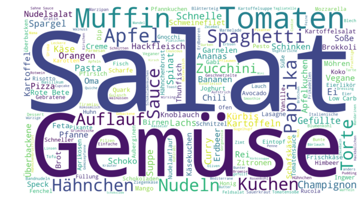

```python
# Display the generated image:
# the matplotlib way:
import matplotlib.pyplot as plt

wordcloud = WordCloud(background_color="white", max_font_size=640, width=1920, height=1080).generate(titletext)
plt.figure(figsize=(10,10))
plt.imshow(wordcloud, interpolation="bilinear")
plt.axis("off")
wordcloud.to_file("images/dishes_chefkoch.png")
plt.show()
```

#### For ingredients

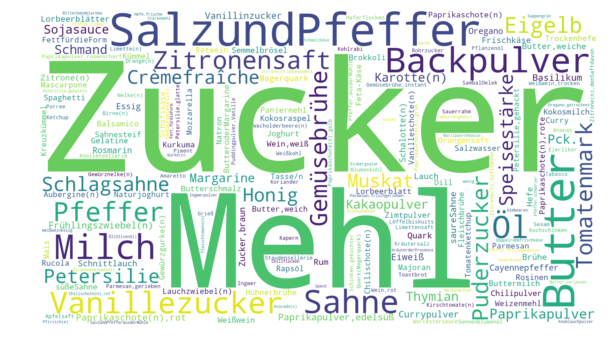

```python
from wordcloud import WordCloud
wordcloud = WordCloud(background_color="white", max_font_size=800, width=1920, height=1080).generate_from_frequencies(ingcounter)
plt.figure(figsize=(10,10))
plt.imshow(wordcloud, interpolation="bilinear")
plt.axis("off")
wordcloud.to_file("images/ingredients_chefkoch.png")
plt.show()
```

### Conclusion: Explorative Analysis

We have used explorative techniques to understand the user and recipe data more deeply and have found interesting dependencies. We can use this knowledge to find the best recipes on the platform much more precisely, as we do not only rely on a single metric, but instead can find users that have published good recipes consistently. Using our scatter matrices we can easily see where to find outliers in the data and some of these outliers will be the users that have performed extraordinarily well.

We have also discovered that a high number of clicks a recipe has collected does not necessarily imply a good quality. Instead, those are most probably the popular mainstream recipes that many people choose because of the dish itself, not necessarily the quality of the recipe. As recipes with many clicks are also more likely to attract more users and gather more clicks, that attribute is distributed exponentially, which is why we might overlook many good recipes if we only judge them by the amount of clicks. To find the actually good recipes that people have enjoyed and decided to come back to for rating them and leaving a comment, we rather should look for recipes with a high amount of favorites (users that have marked that recipe as a favorite).

For selecting a larger number of recipes with consistent quality, we have seen a technique how to select users that have provided good recipes consistently.

The text analysis has provided us insights about:

- which words are used most frequently in recipe titles, which can hint at the most popular recipes and dishes among authors,
- which ingredients are used most frequently, thus are most relevant for a large amount of recipes

Additionally, we can use the generated features during further analysis with machine learning algorithms.

# 2. Trend Analysis

This part of the analysis will focus on how the data has changed and evolved over time. For this purpose, we have two different time axes available for usage:

- the publication date of each recipe
- monthly snapshots of the data over the last 6 months

Obviously, these two time dimensions do not provide a standard data format for time series analysis, as that would require a large number of uniform timesteps. An example for a standard time series is stock market data, that shows a price for each listing per second, which can be aggregated for the day, week, month, etc. In the case of stock market listings, the price is a value that results from multiple factors and can hold it's value or move up or down. The same goes for data from a temperature sensor, for example.

However, the features in the recipe dataset do not behave like that. Instead, they are either immutable after the recipe's publication (e.g. title and ingredients) or they increase over time by accumulating (e.g. popularity metrics). Only the average rating can change in both directions, but with growing number of rating votes the changes become smaller and a singlevote less significant.

## Using the Publication Date

```
2008    24763
2009    22524
2007    21467
2010    18900
2006    17589
2005    13890
2012    13889
2015    13250
2011    13203
2013    12351
2016    11030
2014    10824
2004     8906
2017     6554
2002     5902
2003     5520
2001     2235
2018      668
2000       77
Name: year, dtype: int64
```

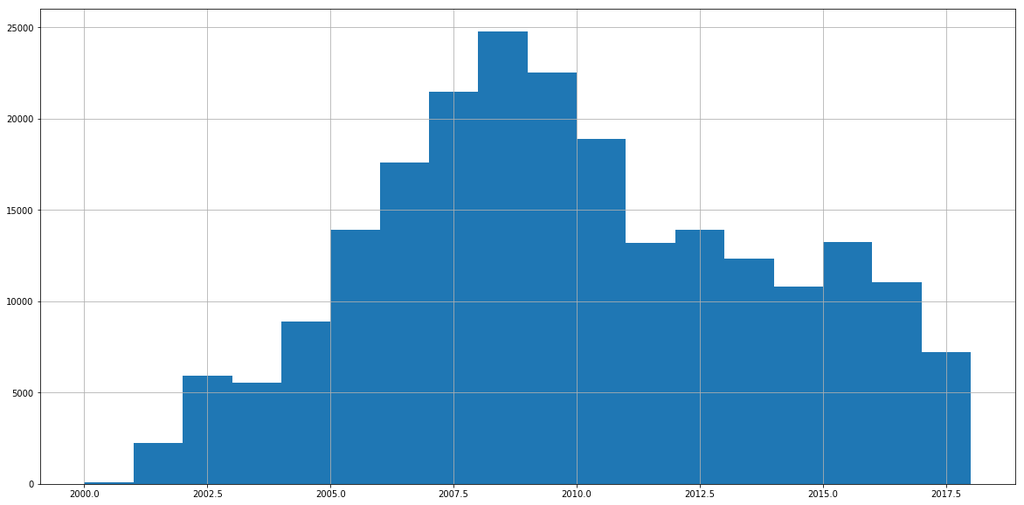

```python
chefdf['year'] = pd.to_numeric(chefdf['year'])
print(chefdf['year'].value_counts())

# Histogram with one bin per year
chefdf['year'].hist(bins=18, figsize=(20,10))
```

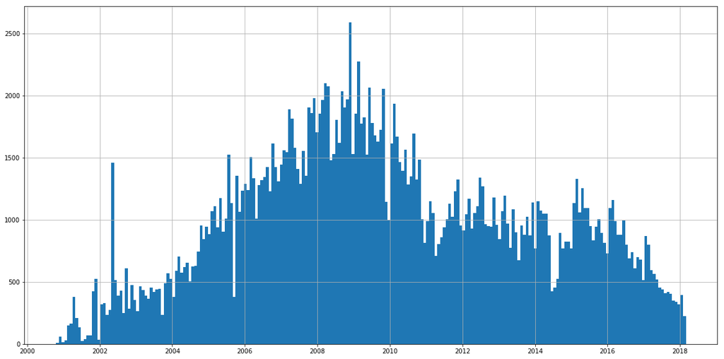

```python
# Histogram with one bin per month
chefdf['date'].hist(bins=228, figsize=(20,10))
```

As there is not an infinite amount of recipes that can be published, it also seems natural that the number of new recipes has declined over time. This is most probably due to the reason that users are not able to come up with new recipes constantly, but instead share the recipes they now in the beginning and then only share more if they occasionally find new recipes. Additionally, the users might check if a similar version of their recipe has been published already, before publishing their own.

However, there could also just be a trend of decreasing interest in such digital communities, possibly because other websites or apps might be more modern and popular nowadays. For example, the websites Pinterest and Instagram have grown to be a very popular source for food recommendations.

To verify these assumptions, a more complex time series analysis could be performed. However, from a business perspective this would not create any further value than we could already gain by analysing the histogram, as we now already know enough about the activity on the website.

## Using the Monthly Website Snapshots

The notebook "Trend_Dataset_Chefkoch.ipynb" can be used to create a dataset that contains the changes in data over a period of 6 months. These changes are extracted from data snapshots that have been taken monthly between October 2017 and March 2018.

```python
import pandas as pd
deltadf = pd.read_csv('exports/trend_deltas_chefkoch.csv', index_col=0)
deltadf.info()
```

```
<class 'pandas.core.frame.DataFrame'>
Int64Index: 215977 entries, 0 to 486612
Data columns (total 27 columns):
name     215977 non-null object
user     215977 non-null object
ar_d1    215977 non-null float64
ar_d2    215977 non-null float64
ar_d3    215977 non-null float64
ar_d4    215977 non-null float64
ar_d5    215977 non-null float64
nr_d1    215977 non-null float64
nr_d2    215977 non-null float64
nr_d3    215977 non-null float64
nr_d4    215977 non-null float64
nr_d5    215977 non-null float64
p_d1     215977 non-null float64
p_d2     215977 non-null float64
p_d3     215977 non-null float64
p_d4     215977 non-null float64
p_d5     215977 non-null float64
sa_d1    215977 non-null float64
sa_d2    215977 non-null float64
sa_d3    215977 non-null float64
sa_d4    215977 non-null float64
sa_d5    215977 non-null float64
sh_d1    215977 non-null float64
sh_d2    215977 non-null float64
sh_d3    215977 non-null float64
sh_d4    215977 non-null float64
sh_d5    215977 non-null float64
dtypes: float64(25), object(2)
memory usage: 46.1+ MB
```

```python
p_trenddf = pd.DataFrame(deltadf.sort_values(by='p_d1',ascending=False)['name'].head(20))
p_trenddf['d2'] = deltadf.sort_values(by='p_d2',ascending=False)['name'].head(20).values
p_trenddf['d3'] = deltadf.sort_values(by='p_d3',ascending=False)['name'].head(20).values
p_trenddf['d4'] = deltadf.sort_values(by='p_d4',ascending=False)['name'].head(20).values
p_trenddf['d5'] = deltadf.sort_values(by='p_d5',ascending=False)['name'].head(20).values
p_trenddf.columns = ['Oct', 'Nov', 'Dec', 'Jan', 'Feb']
p_trenddf
```

|  | Oct | Nov | Dec | Jan | Feb |
| --- | --- | --- | --- | --- | --- |
| 277497 | Nudelsalat | Tiramisu | Wattekuchen | Tiramisu | Schnitzelpfanne |
| 67641 | Schokoladenkuchen | Gefüllte Paprika | Schnitzelpfanne | Schokoladenkuchen | Schüttelkuchen |
| 444386 | Bratäpfel | Joghurt - Beeren - Kuchen | Hefezopf | Brownies | Knoblauchdip zum Reinlegen |
| 9248 | Italienischer Brotsalat | Schnitzelpfanne | Mascarpone - Himbeer - Quark | Kartoffelgratin | Rigatoni al forno |
| 480766 | Schnitzelpfanne | Dinkelbrötchen | Knoblauchdip zum Reinlegen | Schnitzelpfanne | Fruchtig leckere Mangocreme |
| 248447 | Eierpunsch | Tomatensuppe | Himbeerdessert mit Spekulatius | Knoblauchdip zum Reinlegen | Mascarpone - Himbeer - Quark |
| 437769 | Spinatknödel | Apfel - Birnen - Kuchen | Uromas Vanillekipferl | Italienische Partysuppe | Lambada |
| 125070 | Puten - Reis - Pfanne | Knoblauchdip zum Reinlegen | Feine Orangencreme | Johannisbeerkuchen | Blätterteigschnecken |
| 67366 | Schokocrossies | Eierlikörtorte | Vanillekipferl | Hähnchenschenkel vom Blech | Käse-Lauch-Suppe mit Hackfleisch |
| 187028 | Spaghetti Salat | Uromas Vanillekipferl | Zimtsterne | Pflaumenmus | Der beste Käsekuchen der Welt |
| 254215 | Tiramisu | Holunderblütensirup | Saftige Kokosmakronen | Kürbiskuchen | Tagliatelle al Salmone |
| 436109 | Datteln mit Speck | Kürbissuppe mit Ingwer und Kokosmilch | Spätzle | Zitronen - Senf - Dressing | Mozzarella - Hähnchen in Basilikum - Sahnesauce |
| 88073 | Hefezopf | Vanillekipferl | RRs unverwüstliche Ausstech - Plätzchen | Mascarpone - Himbeer - Quark | Schweinefilet-Gratin |
| 243766 | Putengeschnetzeltes | Superschnelle Nutella-Plätzchen | Engelsaugen | Bratäpfel | Low-Carb Big Mac Rolle |
| 198021 | Frühlingsrollen | 1a Spritzgebäck | Superschnelle Nutella-Plätzchen | Tiramisutorte | Lasagne |
| 399771 | Szegediner Gulasch | RRs unverwüstliche Ausstech - Plätzchen | Weihnachtliches Dessert | Käse-Lauch-Suppe mit Hackfleisch | Schwedische Kartoffeln |
| 162280 | Gazpacho | Engelsaugen | Muffins | Bienenstich | Opas Eiersalat |
| 257 | Kürbissuppe mit Ingwer und Kokosmilch | Vanillekipferl | Käse-Lauch-Suppe mit Hackfleisch | Orangencreme | Deftige Gulaschsuppe |
| 12508 | Mohntorte | Zimtsterne | Blaukraut (Rotkraut, Rotkohl) | Brownies | Käsekuchen ohne Boden |
| 274668 | Apfel - Käsekuchen | Käse-Lauch-Suppe mit Hackfleisch | Nussecken | Marmorkuchen | Cremiger Nudelauflauf mit Tomaten und Mozzarella |

Rating a recipe as a favorite usually indicates a higher commitment from the user, which is why we could assume that a visitor would first try out the recipe before rating it. After rating a recipe well, a user will most probably return to that recipe in future uses.

```python
sa_trenddf = pd.DataFrame(deltadf.sort_values(by='sa_d1',ascending=False)['name'].head(20))
sa_trenddf['d2'] = deltadf.sort_values(by='sa_d2',ascending=False)['name'].head(20).values
sa_trenddf['d3'] = deltadf.sort_values(by='sa_d3',ascending=False)['name'].head(20).values
sa_trenddf['d4'] = deltadf.sort_values(by='sa_d4',ascending=False)['name'].head(20).values
sa_trenddf['d5'] = deltadf.sort_values(by='sa_d5',ascending=False)['name'].head(20).values
sa_trenddf.columns = ['Oct', 'Nov', 'Dec', 'Jan', 'Feb']
sa_trenddf
```

|  | Oct | Nov | Dec | Jan | Feb |
| --- | --- | --- | --- | --- | --- |
| 9248 | Italienischer Brotsalat | Tiramisu | Hefezopf | Tiramisu | Schüttelkuchen |
| 198021 | Frühlingsrollen | Dinkelbrötchen | Spätzle | Brownies | Eieraufstrich |
| 125070 | Puten - Reis - Pfanne | Apfel - Birnen - Kuchen | Wattekuchen | Schokoladenkuchen | Tagliatelle al Salmone |
| 277497 | Nudelsalat | Joghurt - Beeren - Kuchen | Lambada | Italienische Partysuppe | Lambada |
| 88073 | Hefezopf | Eieraufstrich | Blumenkohlauflauf | Bärlauchbrot | Rigatoni al forno |
| 436109 | Datteln mit Speck | Agis Gyros in Metaxasauce | Cremiger Nudelauflauf mit Tomaten und Mozzarella | Hähnchenschenkel vom Blech | Shakshuka |
| 67641 | Schokoladenkuchen | Tomatensuppe | Himbeerdessert mit Spekulatius | Kartoffelgratin | Feines Kartoffelgratin |
| 437769 | Spinatknödel | Paprika-Reispfanne mit Joghurtsauce | Pirschbraten | Linsensuppe mit Knoblauch | Schweinefilet in Gorgonzolasoße |
| 67366 | Schokocrossies | Hackbraten mit Käsefüllung | Kräuterbutter | Gulaschsuppe à la Tick | Schwedische Kartoffeln |
| 248447 | Eierpunsch | Spätzle mit Champignon-Rahm-Sauce | Kirschkuchen | Rindergulasch, rostbraun | Sayas leichte Spaghetti Carbonara |
| 134021 | Tiropitakia | Schnelles Hühnerfrikassee | Muffins | Putenoberkeulenbraten mit Mangosauce und Karto... | One Pot Penne mit Parmesan |
| 26490 | Kartoffel - Sauerkraut - Auflauf | Kalbsgulasch mit Pfifferlingen | Rindergulasch | Hackfleisch-Lauch-Suppe | Saftige Gyros-Reis-Pfanne |
| 187028 | Spaghetti Salat | Gefüllte Paprika | Lasagne Bolognese | Reispfanne | Gong Bao Chicken |
| 444386 | Bratäpfel | One Pot Pasta-Kokosmilch-Curry | Feldsalat mit Sahne-Speck-Sauce | Omas Fleisch aus der Kachel | Apfel - Auflauf |
| 162280 | Gazpacho | Kartoffel-Hackfleisch-Topf mit Schmand und Möhren | Warmer Kartoffelsalat mit Speck | Einfaches, vegetarisches Curry | Schnelles Thai-Curry mit Huhn, Paprika und fei... |
| 126501 | Zigeunerschnitzel | Lauchquiche | Raffinierte Bratkartoffeln | Römischer Mangoldfisch mit Rosmarinkartoffeln | Mozzarella - Hähnchen in Basilikum - Sahnesauce |
| 446403 | Puten-Räuberfleisch vom Blech | Hühnerkeule mit Gemüse aus dem Bräter | Ofenkartoffeln mit Sour Cream light | Kaffeelikör | Türkische Pide mit Käse und Sucuk |
| 148986 | Saltimbocca | Kürbis - Lachs - Lasagne | Alpenschmaus | Salat mit Honigchampignons | Gebackene Süßkartoffeln gefüllt mit Pilzen |
| 414663 | Bärlauchbrot | Spinat-Fischstäbchen Auflauf | Vanillekipferl | Gefüllte Paprika mit Joghurtsauce | Bucatini Amatriciana |
| 243766 | Putengeschnetzeltes | Katalanischer Meeresfrüchte-Topf | Kartoffelsuppe mit Erbsen und Mettwürstchen | Mozzarella - Hähnchen in Basilikum - Sahnesauce | Klassischer Grießbrei mit Ei |

A user might print a recipe rather shortly before cooking it, but this assumption could also be wrong if users rather prefer printing many recipes in advance to create their own recipe collections, independent from when they cook them. Unfortunately, we do not know how users generally behave, but we can at least assume that printing a recipe usually happens at a different time than saving it.

Alternatively, one could also analyse relative increases in popularity, so if a recipe moves from rank 400 to 200 in one month, that is probably a larger increase than another moving from rank 20 to 16.

### Traffic Estimation

Unfortunately, we cannot use any of the provided attributes to estimate the traffic on this website (in contrary to kochbar).

# 3. Data Mining / Machine Learning

The final section of the analysis will present the preparation and application of an exemplary machine learning algorithm on the dataset. Due to the limited frame of this project, only one algorithm can be presented in detail. For this purpose, the method of clustering has been selected.

Clustering can be useful to find similar data points in a dataset that does not have any class labels beforehand, which makes it an unsupervised learning algorithm. This means that we can use clustering to group the recipes in clusters that contain similar dishes.

There are many different clustering algorithms that work after different principles and thus are suited of different types of data, depending on the dataset's size, shape and other properties.

## Visualisation with t-SNE

t-SNE is a recently developed and quite popular method for projecting highly dimensional data onto a two- or three-dimensional space for visualisation purposes. This method also helps in distinguishing clusters. As this is a significant dimensionality reduction, using this process before clustering the data points can aid in reducing computation time greatly. One feature that is suited very well for t-SNE is the word vector that we have created for the top1 word in each recipe's title. As a visualisation needs to be simple and clear, we will only use a small subset of data in during this process.

```python
import pandas as pd
featuredf = pd.read_csv('exports/featuredf_100_chefkoch.csv', index_col=0)
```

```python
import fasttext
model = fasttext.load_model('word_embeddings/prep_model.bin')
```

```python
# Create a list of the 100 most common words for visualisation:
toplist1 = [w for w in toplist1 if w is not None]
top = Counter(toplist1)
top100_words = []
for word in top.most_common(100):
    top100_words.append(word[0])

top100_words[:10]
```

```
['Salat',
 'Tomaten',
 'Torte',
 'Gemüse',
 'Kuchen',
 'Apfel',
 'Sauce',
 'Auflauf',
 'Zucchini',
 'Käse']
```

```python
from sklearn.manifold import TSNE
import matplotlib.pyplot as plt
%matplotlib inline

def tsne_plot(model, perplexity):
    "Creates and TSNE model and plots it"
    labels = []
    tokens = []

    for word in top100_words:
        tokens.append(model[word])
        labels.append(word)

    tsne_model = TSNE(perplexity=perplexity, n_components=2, init='pca', n_iter=5000, random_state=23)
    new_values = tsne_model.fit_transform(tokens)

    x = []
    y = []
    for value in new_values:
        x.append(value[0])
        y.append(value[1])

    Z = []

    plt.figure(figsize=(10, 10))
    for i in range(len(x)):
        Z.append([x[i], y[i]])
        plt.scatter(x[i],y[i])
        plt.annotate(labels[i],
                     xy=(x[i], y[i]),
                     xytext=(5, 2),
                     textcoords='offset points',
                     ha='right',
                     va='bottom')
    plt.show()

    return Z
```

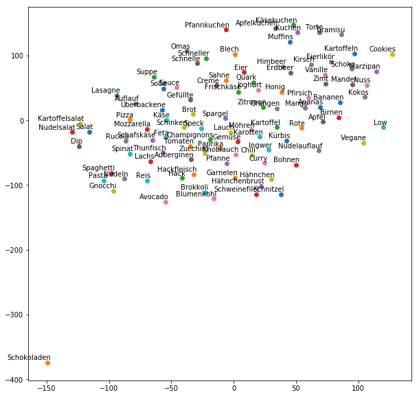

```python
Z1 = tsne_plot(model, 25)
```

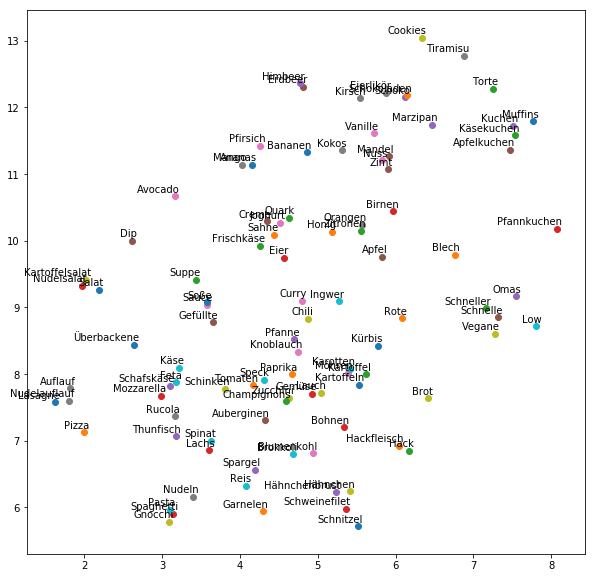

```python
Z2 = tsne_plot(model, 50)
```

```python
top_vectors = pd.DataFrame(top100_words, columns=['word'])
top_vectors['vectors'] = top_vectors['word'].apply(lookup_vector)
top_vectors.head(10)
```

|  | word | vectors |
| --- | --- | --- |
| 0 | Salat | [0.5253750681877136, -0.2820751667022705, -0.4... |
| 1 | Tomaten | [0.05337012931704521, 0.28184106945991516, 0.3... |
| 2 | Torte | [0.19287148118019104, 0.30406495928764343, -0.... |
| 3 | Gemüse | [0.258699506521225, -0.1675672084093094, -0.00... |
| 4 | Kuchen | [0.5229253172874451, -0.08780337870121002, -0.... |
| 5 | Apfel | [0.06887681037187576, 0.14354068040847778, 0.0... |
| 6 | Sauce | [0.09283524751663208, -0.3264232873916626, -0.... |
| 7 | Auflauf | [0.5600726008415222, -0.539618194103241, -0.14... |
| 8 | Zucchini | [0.10060034692287445, 0.07551064342260361, 0.4... |
| 9 | Käse | [0.5144494771957397, -0.15242810547351837, -0.... |

```python
top_vectors.to_csv('exports/top_vectors_chefkoch.csv')
```

The t-SNE visualisation shows how well similar words are placed close to each other. There are many examples for which this has worked very well, for example fruits and dessert, salad, vegetables, spices, noodles and rice, fish or chicken. There is also something quite interesting in the case of pork meat: while filet and schnitzel are placed close to chicken and fish, ham and bacon lie much closer to cheese, lasagne and vegetables.

This shows that, even in the two-dimensional space, the word embeddings of the most common word in a recipe's title can be used to cluster it with similar recipes. In the 100-dimensional space, such clusterings will probably be even more accurate.

### Clustering with DBSCAN

As we have seen in the t-SNE visualisation, points with similar words are more dense. However, they are not all placed in globular shape, but can instead form a line or a circle. Thus, we need to choose a clustering algorithm that is density-based. DBSCAN is a common density-based clustering algorithm.

For simplicity and comparability, we will perform a clustering on the vectors that were created by t-SNE, so the formed clusters can directly be compared with the respective plot from above.

```python
labels = []
tokens = []

for word in top100_words:
    tokens.append(model[word])
    labels.append(word)

tokens = np.array(tokens)
Z1 = np.array(Z1)
Z2 = np.array(Z2)
```

```python
import numpy as np

from sklearn.cluster import DBSCAN
from sklearn import metrics
from sklearn.datasets.samples_generator import make_blobs
from sklearn.preprocessing import StandardScaler

X = Z2

# Compute DBSCAN
db = DBSCAN(eps=0.5, min_samples=3).fit(X)
core_samples_mask = np.zeros_like(db.labels_, dtype=bool)
core_samples_mask[db.core_sample_indices_] = True
labels = db.labels_

print(labels)
```

```
[ 0  1 -1  1  2 12  3  4  1  5  2  1  1  6  7  3  1  6  8  5 10  9  9  5 11
 -1  9 10  1 11  1 -1  3  0  1  2  1 12  1  6  1 -1  2 -1  5 13  1  7  0 -1
 14 -1  1  8 -1  9 10 14 -1  5 -1 12 12 12 -1 -1 10  4  1  1  3  7  9  5  5
 10 -1 -1 13  1  4 11 -1 -1  8 10 14  7  6 -1  8 -1 13  9 13  1 -1  5 -1  1]
```

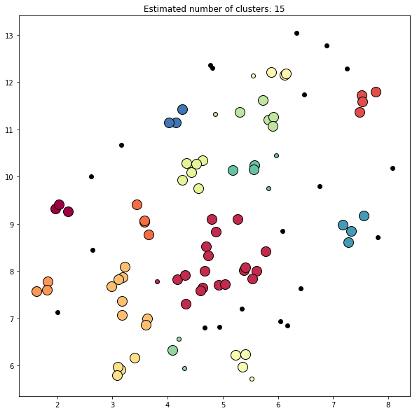

```python
import matplotlib.pyplot as plt

# Black removed and is used for noise instead.
n_clusters_ = len(set(labels)) - (1 if -1 in labels else 0)
unique_labels = set(labels)
colors = [plt.cm.Spectral(each)
          for each in np.linspace(0, 1, len(unique_labels))]

plt.figure(figsize=(10,10))
for k, col in zip(unique_labels, colors):
    if k == -1:
        # Black used for noise.
        col = [0, 0, 0, 1]

    class_member_mask = (labels == k)

    xy = X[class_member_mask & core_samples_mask]
    plt.plot(xy[:, 0], xy[:, 1], 'o', markerfacecolor=tuple(col),
             markeredgecolor='k', markersize=14)

    xy = X[class_member_mask & ~core_samples_mask]
    plt.plot(xy[:, 0], xy[:, 1], 'o', markerfacecolor=tuple(col),
             markeredgecolor='k', markersize=6)

plt.title('Estimated number of clusters: %d' % n_clusters_)
plt.show()
```

```python
# Merge the class labels with the dataset:
top_vectors['label'] = labels
top_vectors = top_vectors.sort_values(by='label')
```

```python
top_vectors.query('label > 5 and label < 12')
```

|  | word | vectors | label |
| --- | --- | --- | --- |
| 39 | Pasta | [0.41407933831214905, -0.2214946746826172, 0.2... | 6 |
| 17 | Nudeln | [0.4210481643676758, -0.49978044629096985, 0.2... | 6 |
| 88 | Gnocchi | [0.2358337938785553, -0.12508217990398407, 0.4... | 6 |
| 13 | Spaghetti | [0.29682567715644836, -0.2333211898803711, 0.2... | 6 |
| 71 | Schokoladen | [-0.03279418498277664, -0.24889139831066132, -... | 7 |
| 47 | Kirsch | [0.15034843981266022, 0.3117665648460388, -0.4... | 7 |
| 87 | Eierlikör | [0.6155270934104919, 0.16933009028434753, -0.8... | 7 |
| 14 | Schoko | [0.050747837871313095, -0.14573490619659424, -... | 7 |
| 84 | Hähnchenbrust | [0.16490481793880463, -0.5731877088546753, 0.1... | 8 |
| 53 | Schweinefilet | [0.18028958141803741, -0.4549875259399414, 0.1... | 8 |
| 90 | Schnitzel | [0.3049103319644928, -0.5108455419540405, 0.19... | 8 |
| 18 | Hähnchen | [-0.25304102897644043, -0.33448708057403564, -... | 8 |
| 26 | Joghurt | [0.29092147946357727, 0.0031468868255615234, -... | 9 |
| 55 | Creme | [0.06380727142095566, -0.011579886078834534, -... | 9 |
| 22 | Quark | [0.39774826169013977, 0.05041850358247757, -0.... | 9 |
| 21 | Sahne | [0.07050749659538269, -0.2966679334640503, -0.... | 9 |
| 72 | Frischkäse | [0.0724923238158226, -0.01793394237756729, -0.... | 9 |
| 93 | Eier | [0.4815751612186432, -0.3798500895500183, -0.0... | 9 |
| 27 | Kokos | [-0.07508566975593567, -0.5728944540023804, -0... | 10 |
| 20 | Bananen | [0.4414433538913727, -0.04153750464320183, -0.... | 10 |
| 66 | Nuss | [-0.061241500079631805, -0.36244654655456543, ... | 10 |
| 85 | Zimt | [0.06980663537979126, 0.12425746023654938, 0.0... | 10 |
| 75 | Mandel | [0.08424026519060135, -0.024320006370544434, 0... | 10 |
| 56 | Vanille | [0.2544391453266144, -0.1328975409269333, -0.5... | 10 |
| 24 | Spargel | [0.5074779987335205, -0.4225254952907562, 0.35... | 11 |
| 81 | Garnelen | [0.3389413058757782, 0.009764561429619789, 0.3... | 11 |
| 29 | Reis | [0.12365343421697617, -0.4543071687221527, -0.... | 11 |

We can see that these words have been labelled quite well.

### Summary Data Mining

We have seen how the data can be transformed by dimensionality reduction to create two-dimensional presentations that can be plotted well. Additionally, the results from clustering with DBSCAN have shown that even the data with reduced dimensions can be clustered very accurately into recipe categories.

For an alternative approach to clustering, the ingredients could be used as well. By increasing the dimensionality of the dataset before applying t-SNE (i.e. one-hot encoding with 1,000 ingredients or more, for example), the representation would probably reach a higher accuracy. However, as this is an unsupervised learning problem, we cannot perform an automatic accuracy testing, but we can see by looking at the results that the chosen algorithms have worked very well.

When applying these techniques to categorise all recipes in the dataset, it will be better to use more than just the 100 most frequent words, of course. Then, the t-SNE visualisation will most probably not be readable anymore, but the results from clustering can then be applied to many different recipes and work very well.